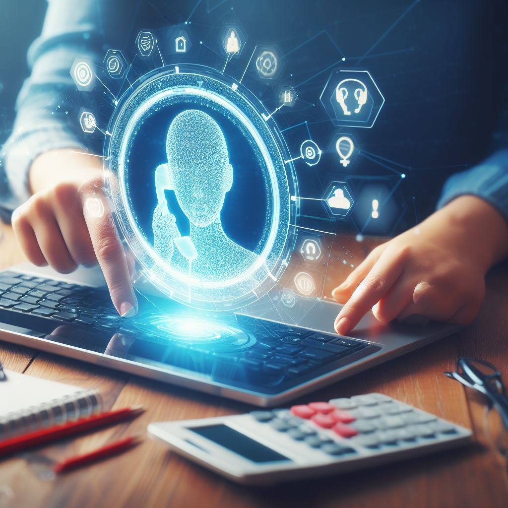

# Online Resources

Online resources that might help with getting through the non-academic side of things.

We’re all under pressure and find things difficult, from time to time. This page is intended to highlight some resources that may be useful if you’re feeling the strain.

**Note**

If any of the links on this page are broken or outdated, please email Leighton Pritchard, or feel free to submit a pull request or issue report at [GitHub](https://github.com/sipbs-compbiol/sipbscompbiol-pda).

## 1 University Resources

- Who should I talk to? - *A table of which university service to contact first, depending on the situation.*

### 1.1 Health and Welfare

- [Departmental Disability Contacts](https://www.strath.ac.uk/professionalservices/disabilityandwellbeing/disabilitysupport/departmentaldisabilitycontactsddc/)
- [Disability and Wellbeing Support](https://www.strath.ac.uk/professionalservices/disabilityandwellbeing/disabilitysupport/) - *University pages for disability support*
- A Guide To Stress-Free Exams - *A document produced by SEES with advice for exam preparation.*
- [Mental Health and Wellbeing Support](https://www.strath.ac.uk/professionalservices/disabilityandwellbeing/mentalhealthwellbeingsupport/) - *University pages for mental health support*
- [Student Counselling](https://studentsupport.strath.ac.uk/counselling) - *University counselling service for students.*

### 1.2 Personal Circumstances

- [Information for Student Carers](https://www.strath.ac.uk/professionalservices/accessequalityinclusionservice/wideningaccess/gettingin/studentcarers/) - *Support for students in a caring role.*

### 1.3 Finances

- [Cost of Living Advice for Students](https://www.strath.ac.uk/studywithus/feesfunding/costoflivingforstudents/) - *University advice for getting all the money you’re entitled to, and for living on a restricted budget.*
- [Digital Inclusion Programme](https://www.strath.ac.uk/studywithus/scholarships/digitalinclusionequipmentloanscheme/) - *Support to purchase IT equipment to aid in your learning.*
- [Mature Student Hardship Fund](https://www.strath.ac.uk/studywithus/scholarships/maturestudentshardshipfund/) - *Additional financial support for mature students.*
- [Scholarships and Funding](https://www.strath.ac.uk/studywithus/scholarships/?) - *Scholarship and funding opportunities at the university.*

### 1.4 Academic Support

- [Academic Support](https://www.strath.ac.uk/studywithus/strathlife/academicsupport/) - *The university’s academic support service*
- [Skills Boost](https://guides.lib.strath.ac.uk/skillsboost) - *A 45-minute self-study session from the University Library.*
- [Study Skills Workshops](https://www.strath.ac.uk/professionalservices/accessequalityinclusionservice/wideningaccess/gettingready/studyskillsworkshops/) - *The university runs workshops for developing study skills.*
  - *The Library also run [drop-in sessions](https://www.strath.ac.uk/professionalservices/informationservices/libraryithelp/skillsboostdrop-insessions/) for “Skills Boost”.*
- [Studying From Home](https://www.strath.ac.uk/studywithus/strathlife/tipsforstudyingfromhome/) - *Advice on how to study effectively from home*

### 1.5 Careers

- [University Career Hub](https://careerhub.strath.ac.uk/students/login?ReturnUrl=%2fstudents%2fdocs%2fdetail%2f12%2feffective-cvs) - *Central access point for university careers support*

### 1.6 Student Union Resources

- [Advice Hub](https://www.strathunion.com/support/) - *Central point of contact for advice.*
- [Hear to Listen](https://www.strathunion.com/support/heartolisten/) - *Informal, confidential wellbeing support from the Student Union*
- [Housing](https://www.strathunion.com/support/housing/) - *SU support and advice with housing.*
- [Money](https://www.strathunion.com/support/money/) - *SU support and advice with money.*

## 2 Academic Support

- [How To Study](https://lsc.cornell.edu/how-to-study/) - *Good advice from Cornell University.*
- [Study Skills](https://www.advance-he.ac.uk/knowledge-hub/study-skills) - *Study Skills advice from Advance HE.*
- [Study Skills](https://help.open.ac.uk/browse/study-skills) - *Open University Study Skills advice.*
- [Study Skills For College Students](https://www.collegeatlas.org/college-study-guides.html) - *College Atlas advice for college students.*
- [Top 10 Study Skills](https://www.lynchburg.edu/academics/tutoring-and-academic-support/top-10-study-skills/) - *Top 10 Study Skills, from the University of Lynchburg.*

### 2.1 Active Reading

Reading takes time, however you do it. “Active reading” attempts to focus effort on getting meaning from the text efficiently - reducing it to its key points. This can help with mind-mapping, note-taking and other techniques. It’s also transferable to taking notes from lectures, either live or pre-recorded.

- [Active Reading](https://www.lynchburg.edu/academics/tutoring-academic-support/active-reading/) - *Advice from the University of Lynchburg.*
- [Active Reading Strategies](https://mcgraw.princeton.edu/active-reading-strategies) - *McGraw-Hill’s guidance on active reading.*
- [Seven Active Reading Strategies](https://www.thoughtco.com/active-reading-strategies-1857325) - *Strategies for active reading, from ThoughtCo.*

### 2.2 Taking effective notes

It’s a pain to have to go back to the original material and read through it all/watch it all. Identifying what’s important in the material *the first time around* is a skill that it’s possible to train and develop.

- [How To Take Notes](https://www.lifehack.org/articles/featured/advice-for-students-taking-notes-that-work.html) - *Three approaches from LifeHack.*
- [How To Take Study Notes](https://www.oxfordlearning.com/5-effective-note-taking-methods/) - *Five methods from Oxford Learning.*
- [Strategies For Taking Good Lecture Notes](https://depts.washington.edu/ic/content/notes.php?style=graphics) - *The University of Washington’s advice for students.*
- [Take Effective Notes](https://www.intelligent.com/take-effective-notes/) - *Seven strategies from `intelligent.com`.*
- [Taking Effective Notes](https://usm.maine.edu/learning-commons/note-taking-active-reading/) - *Advice from the University of Maine.*
- [The Best Techniques For Taking Notes](https://lifehacker.com/back-to-basics-perfect-your-note-taking-techniques-484879924) - *Lifehacker’s advice on note-taking.*

### 2.4 Mind-Mapping

I found mind-mapping useful when I was a student. It let me link topics and ideas in an order that made sense to me and let me see the connections that led from one to the other. That was good for exams, and for just understanding the overall structure of a topic. I know quite a few lecturers who use them to summarise seminars they attend, and others who use the technique to plot out papers and lectures. It doesn’t work for everyone or every topic, but you might find it useful.

- [Mind Mapping](https://www.vanderbilt.edu/bold/mind-mapping/) - *A guide, with links to tools, from Vanderbilt University.*
- [Mind Mapping](https://canvas.hull.ac.uk/courses/610/pages/mind-mapping) - *How to use Mind-Mapping, from the University of Hull.*
- [Mindmapping](https://www.brookes.ac.uk/students/academic-development/online-resources/mindmapping/) - *Guidance and links, at Oxford Brookes University.*

## 3 Careers

- Life Sciences CV Checklist - *CV checklist produced by Strathclyde’s Careers Service.*
- Writing Professional Emails - *Email can seem like an informal medium, but when applying for jobs/internships/whatever you will be assessed on your ability to communicate appropriately for the situation (i.e. professionally).*

## 4 Physical and Mental Health

- Imposter Syndrome - *Imposter Syndrome is common among students and academics. We’re willingly putting ourselves into positions where we are not - *yet* - fully comfident or on top of the work we’re doing. This document proposes some strategies and lists resources that might be helpful if you’re feeling it. - LP*
- Mental Health for Undergraduates - *A US-centric poster (the phone numbers won’t work) highlighting aspects of mental health for students.*
- [Think Positive Scotland](https://thinkpositive.scot/) - *Mental health support for students in Scotland.*

## 5 Charities and Other Support

We all need help sometimes. And sometimes more than the university can provide directly. Just in case.

- [Citizens Advice Scotland](https://www.citizensadvice.org.uk/scotland/) - *Legal, money, health.*
- [Glasgow Helps](https://www.glasgowhelps.org/) - *A central hub for finding the charity or organisation you need for support.*
- [Glasgow NE Foodbank](https://glasgowne.foodbank.org.uk/) - *Food and nutrition.*
- [Glasgow NW Foodbank](https://glasgownw.foodbank.org.uk/) - *Food and nutrition.*
- [Glasgow SE Foodbank](https://glasgowse.foodbank.org.uk/) - *Food and nutrition.*
- [Glasgow SW Foodbank](https://glasgowsw.foodbank.org.uk/) - *Food and nutrition.*
- [Mind](https://www.mind.org.uk/) - *Mental health and wellbeing*
- [Samaritans Scotland](https://www.samaritans.org/scotland/samaritans-in-scotland/) - *Mental health and wellbeing*
- [SAMH](https://www.samh.org.uk/) - *Mental health and wellbeing*
- [Shelter Scotland](https://scotland.shelter.org.uk/) - *Housing*